# Introduction to R

[figure not shown]

[figure not shown]

[figure not shown]

[figure not shown]

[figure not shown]

[figure not shown]

[figure not shown]

[figure not shown]

# Apply

### Apply

##### Using the “Apply” family of functions

#### Introduction

The “apply” family of functions keep you from having to write loops to perform some operation on every row or every column of a matrix or data frame, or on every element in a list.

###### The `apply()` function

The `apply()` function is a powerful device that operates on arrays and, in particular, matrices. The `apply()` function returns a vector (or array or list of values) obtained by applying a specified function to either the row or columns of an array or matrix. To specify use for rows or columns, use the additional argument of 1 for rows, and 2 for columns.

```
# create a matrix of 10 rows x 2 columns
m <- matrix(c(1:10, 11:20), nrow = 10, ncol = 2)

# mean of the rows

apply(m, 1, mean)
# [1]  6  7  8  9 10 11 12 13 14 15

# mean of the columns
apply(m, 2, mean)
#[1]  5.5 15.5
```

#### Apply functions

A group of functions useful for avoiding loops:

1. lapply,
2. sapply,
3. apply,
4. tapply

lapply and sapply are used to iterate along a list or a vector.

lapply( listname , length)will return a list with components the length of the components of the list.

sapply( listname , length) will return a vector with elements the lengths of the components of the list.

#### tapply

apply and tapply operate in a similar way on parts of arrays or vectors.

apply and tapply have extra parameters, to indicate which part of the array or vector to use.

For apply it is the dimension(s) of the array over which to iterate. e.g. apply(matrixname,2,sum,na.rm=TRUE) will produce the sum of each column of the matrix, after missing values have been removed.

Note how to pass extra arguments to the function to be applied.

Can be used on data frames, but will turn them into matrices first. If there are factor variables, all the variables will end up as character.

#### lapply()

The local version of `apply()` is `lapply()`, which computes a function for each argument of a list., provided each argument is compatible with the function argument (e.g. that is numeric).

The `lapply()` command returns a list of the same length as a list “X”, each element of which is the result of applying a specified function to the corresponding element of X.

#### sapply()

A user friendly version of lapply() is sapply().

The `sapply()` command is a variant of `lapply()` – returning a matrix instead of a list - again of the same length as a list X, each element of which is the result of applying a specified function to the corresponding element of X.

```
> x <- list(a=1:10, b=exp(-3:3), logic=c(T,F,F,T))
>
> # compute the list mean for each list element
>
> lapply(x,mean)
$a
[1] 5.5

$b
[1] 4.535125

$logic
[1] 0.5
>
> sapply(x,mean)
       a        b    logic
5.500000 4.535125 0.500000
>
```

Complex Simulation Program

1. Create a function called SumDice().
2. Apply SumDice() n times to an initial value x
3. Graph the data

[output not shown]

#### Binomial coefficients

$$n \choose k = \frac{n!}{k!(n-k)!}$$

The command takes the form

```
choose(n,k)
```

```
> choose(9,2)
[1] 36
```

The factorial of a number can be computers using the `factorial()` command.

```
> factorial(4)
[1] 24
```

# Data Frames

### Data Frames

Another way that information is stored is in data frames. This is a way to take many vectors of different types and store them in the same variable. The vectors can be of all different types. For example, a data frame may contain many lists, and each list might be a list of factors, strings, or numbers.

There are different ways to create and manipulate data frames. Most are beyond the scope of this introduction. They are only mentioned here to offer a more complete description.

###### Data Frames

Technically, a data frame in is a very important type of data object; a type of table where the typical use employs the rows as observations (or cases) and the columns as variables. Inter alia, a data frame differs from a matrix in that it can contain character values. Many data sets are stored as data frames. Let us consider the following two variables; age and height.

```
> age=18:29
> age
[1] 18 19 20 21 22 23 24 25 26 27 28 29
```

In similar fashion, we entered the average heights in a vector called height.

```
>height=c(76.1,77,78.1,78.2,78.8,79.7,79.9,81.1,81.2,81.8,82.8,83.5)
> height
[1] 76.1 77.0 78.1 78.2 78.8 79.7 79.9 81.1 81.2 81.8 82.8 83.5
```

We will now use ’s command to create our first data frame and store the results in the data frame “village”.

```
> village=data.frame(age=age,height=height)
```

How do we access the data in each column? One way is to state the variable containing the data frame, followed by a dollar sign, then the name of the column we wish to access (as with Lists earlier). For example, if we wanted to access the data in the “age” column, we would do the following:

```
 > village$age
 [1] 18 19 20 21 22 23 24 25 26 27 28 29
```

##### Data Frames

A data frame

- can be thought of as a data matrix or data set;
- is a generalization of a matrix;
- is a list of vectors and/or factors of the same length;
- has a unique set of row names

Data in the same position across columns come from the same experimental unit.

We can create data frames from pre-existing variables:

```
> d <- data.frame(mean_weight, Gender)
```

```
# Creating a more complex data frame

A <- data.frame(
      name=c("a","b","c"),
      ownership=c("Case 1","Case 1","Case 2"),
      listed.at=c("NSE",NA,"BSE"),
          # Firm "b" is unlisted.
      is.listed=c(TRUE,FALSE,TRUE),
          # R convention
          # boolean variables are named "is.something"
      x=c(2.2,3.3,4.4),
      date=as.Date(c("2004-04-04","2005-05-05","2006-06-06"))
)
```

```
# Characteristics of a Data Frame
summary(A)
dim(A)
nrow(A) ; ncol(A)
names(A)
```

Data set : mtcars

R contains several embedded data sets. One that is commonly used is mtcars

```
>mtcars
```

(for some background on mtcars, type ?mtcars)

Each of the columns has a name. Use the commands `names()` and `dim()` to find more information about mtcars.

Another useful command is `summary()`. It will give revelant information on the data object.

We can use the command rownames() to access the names of each row.

To access a particular column, use the dollar sign to specify it

```
>mtcars$mpg
```

We can now perform calculations on this column.

[output not shown]

[output not shown]

# Grubbs’ Test

### Grubbs’ Test

#### Grubbs’ Test

Grubbs’ test is a formal hypothesis test for assessing whether or not a data set contains an outlier. This data set is univariate and approximately normal distributed. This test is designed for assessing one outlier only.  
If more outliers are suspected, alternative tests, such as the Tietjen-Moore test, are recommended. Hypotheses: Grubbs’ test is defined for the hypothesis:

[Ho] : There are no outliers in the data set  
[Ha] : There is exactly one outlier in the data set

```
install.packages("outliers")
library(outliers)
#Package Author : Lukasz Komsta (UMLUB, Poland)

grubbs.test(DAT002)
```

# Lattice Examples

```r
library(lattice)
attach(mtcars)
```

```r
# create factors with value labels
gear.f<-factor(gear,levels=c(3,4,5),
labels=c("3gears","4gears","5gears"))
cyl.f <-factor(cyl,levels=c(4,6,8),
labels=c("4cyl","6cyl","8cyl"))
```

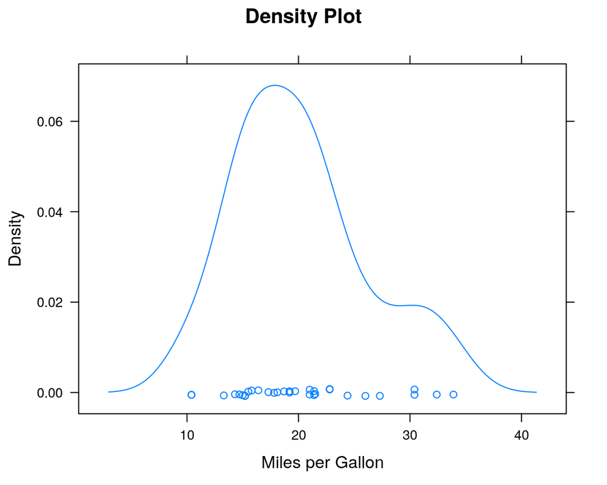

```r
# kernel density plot
densityplot(~mpg,
main="Density Plot",
xlab="Miles per Gallon")
```

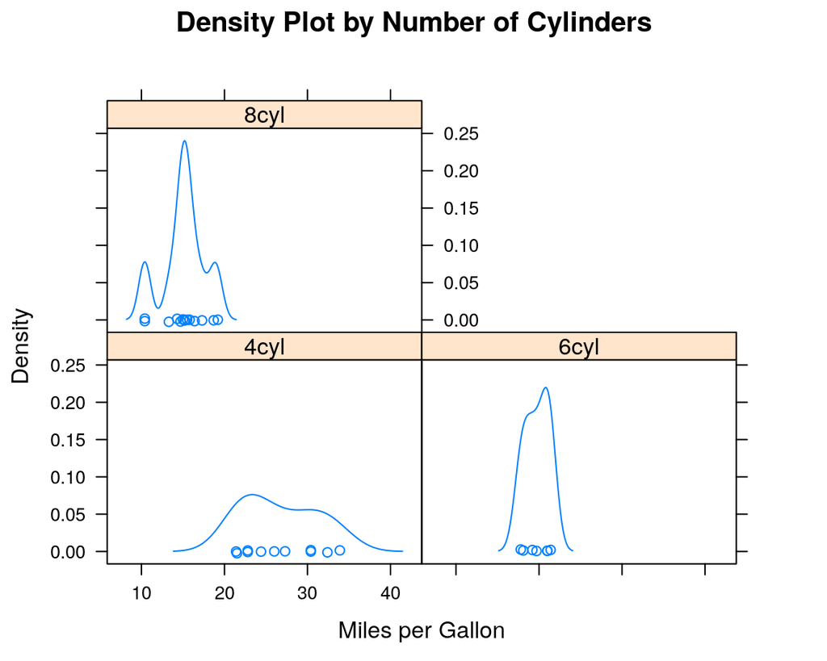

```r
# kernel density plots by factor level
densityplot(~mpg|cyl.f,
main="Density Plot by Number of Cylinders",
xlab="Miles per Gallon")
```

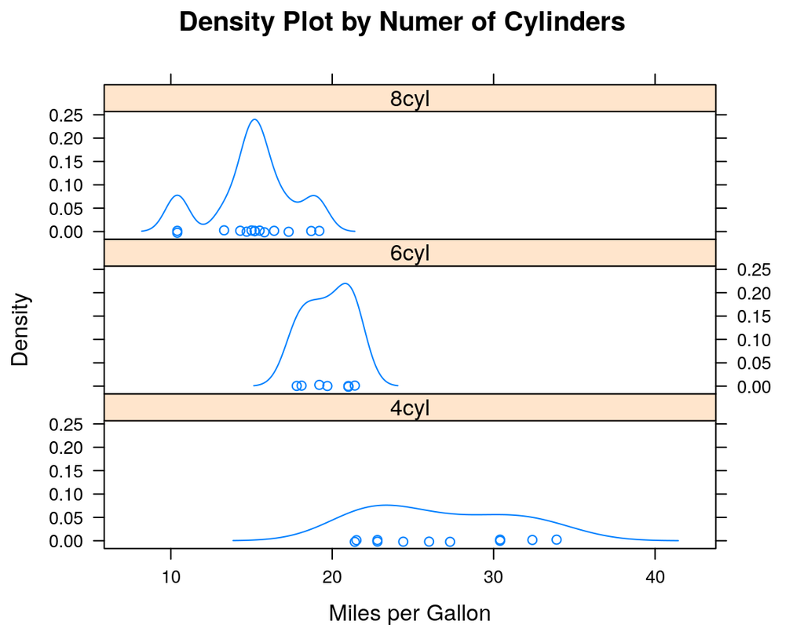

```r
# kernel density plots by factor level (alternate layout)
densityplot(~mpg|cyl.f,
main="Density Plot by Numer of Cylinders",
xlab="Miles per Gallon",
layout=c(1,3))
```

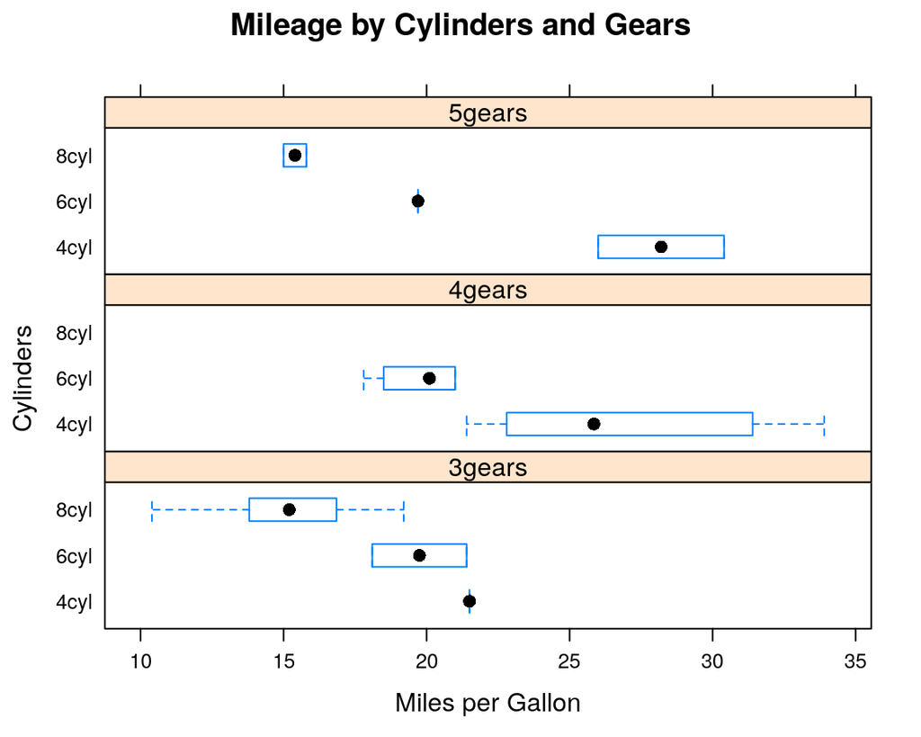

```r
# boxplots for each combination of two factors
bwplot(cyl.f~mpg|gear.f,
ylab="Cylinders", xlab="Miles per Gallon",
main="Mileage by Cylinders and Gears",
layout=(c(1,3))
)
```

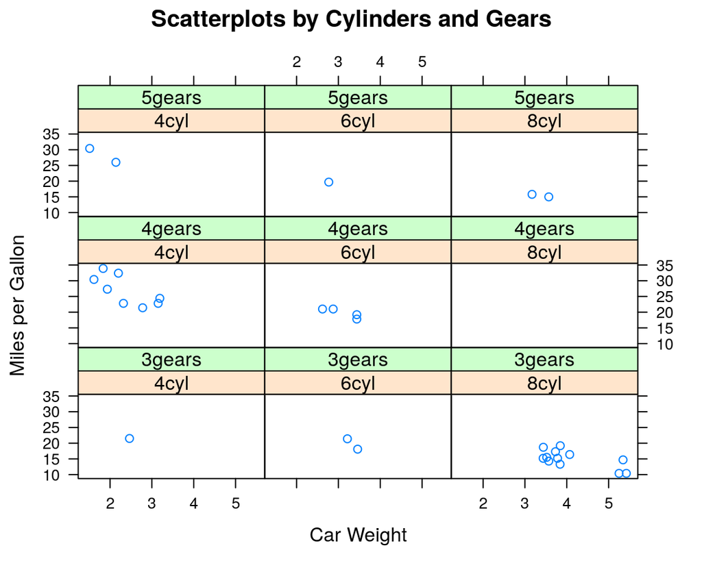

```r
# scatterplots for each combination of two factors
xyplot(mpg~wt|cyl.f*gear.f,
main="Scatterplots by Cylinders and Gears",
ylab="Miles per Gallon", xlab="Car Weight")
```

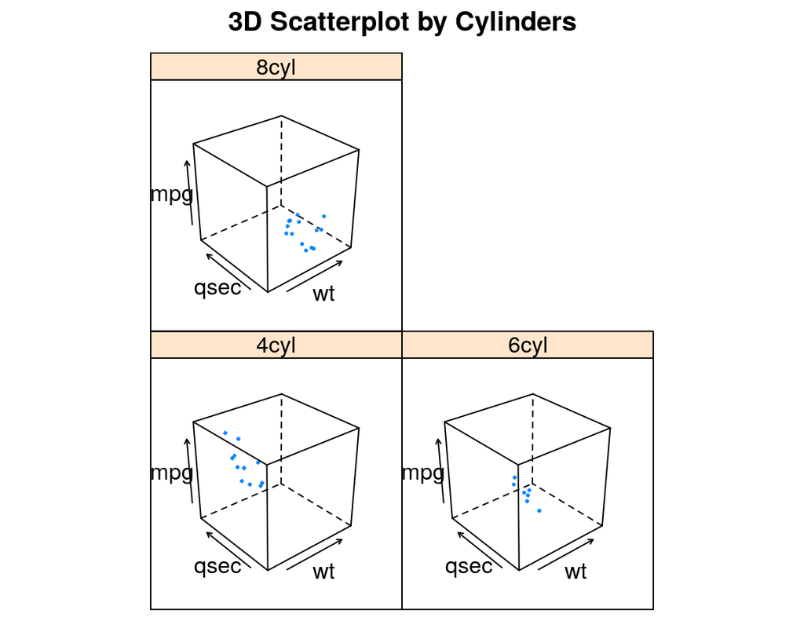

```r
# 3d scatterplot by factor level
cloud(mpg~wt*qsec|cyl.f,
main="3D Scatterplot by Cylinders")
```

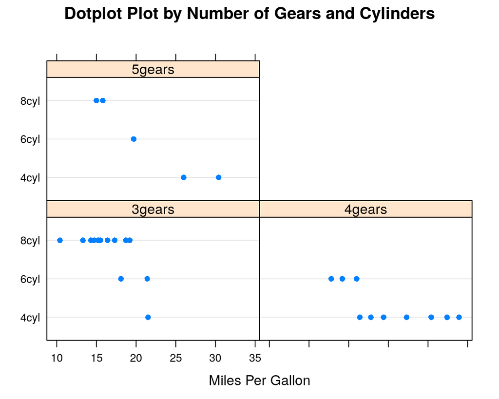

```r
# dotplot for each combination of two factors
dotplot(cyl.f~mpg|gear.f,
main="Dotplot Plot by Number of Gears and Cylinders",
xlab="Miles Per Gallon")
```

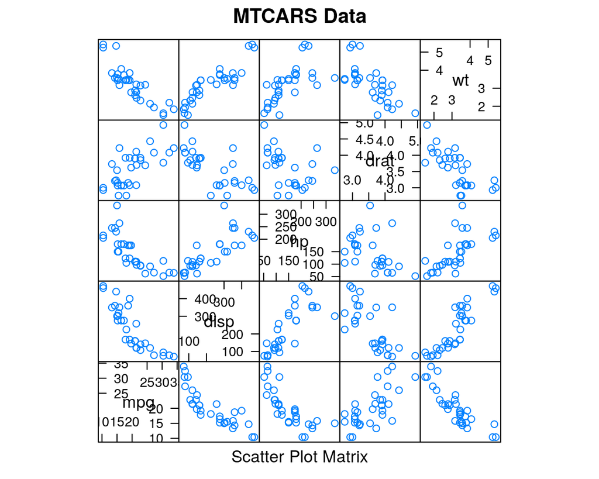

```r
# scatterplot matrix
splom(mtcars[c(1,3,4,5,6)],
main="MTCARS Data")
```

# Matrices

### Matrices

#### Creating a matrix

Matrices can be created using the matrix() command.

Additionally you can specify if the values are to be allocated by row or column. By default they are allocated by column.

```
Vec1 = c(1,4,5,6,4,5,5,7,9)  # 9 elements

A = matrix(Vec1,nrow=3)      #3 by 3 matrix, assigned by column.

A

#      [,1] [,2] [,3]
# [1,]    1    6    5
# [2,]    4    4    7
# [3,]    5    5    9
```

Notice how the rows and column are preceded with row and column indexes. To assign by row, we must specify it by setting the appropriate argument accordingly.

```
#3 by 3 matrix. Values assigned by row.
C= matrix(  c(1,6,7,0.6,0.5,0.3,1,2,1), ncol=3 , byrow =TRUE)

C
     [,1] [,2] [,3]
[1,]  1.0  6.0  7.0
[2,]  0.6  0.5  0.3
[3,]  1.0  2.0  1.0
```

### Accessing Rows and Columns

Particular rows and columns of a data object (matrix as well as other objects such as data frames) can be accessed by specifying the row number or column number, leaving the other value blank.

```
A[1,]   # access first row of A
#[1] 1 6 5

C[,2]   # access second column of C
#[1] 6.0 0.5 2.0
```

Naturally - particular elements may be accessed by specifying the row number and column number

```
A[1,1]
# [1] 1

# This is not just for matrices.
# It is for all suitable data objects.

iris[,1]
iris[,1:3]
iris[2,]
iris[2,3]

mtcars[2:5,4:6]
```

### Addition and subtractions

For matrices, addition and subtraction works on an element-wise basis. The first elements of the respective matrices are added, and so on.

```
A+C

#     [,1] [,2] [,3]
#[1,]  2.0 12.0 12.0
#[2,]  4.6  4.5  7.3
#[3,]  6.0  7.0 10.0

A-C

#     [,1] [,2] [,3]
#[1,]  0.0  0.0 -2.0
#[2,]  3.4  3.5  6.7
#[3,]  4.0  3.0  8.0
```

#### Matrix Multiplication

To multiply matrices, we require a special operator for matrices; “%*%”.

If we just used the normal multiplication, we would get an element-wise multiplication. This type of operation is very useful as a substitute for “for” loops on many occasions.

```
 A %*% C
#     [,1] [,2] [,3]
#[1,]  9.6 19.0 13.8
#[2,] 13.4 40.0 36.2
#[3,] 17.0 50.5 45.5

 A*C
#     [,1] [,2] [,3]
#[1,]  1.0   36 35.0
#[2,]  2.4    2  2.1
#[3,]  5.0   10  9.0
```

### Basic Matrix Calculations

1. Inverting a matrix

To invert a matrix we use the command solve() with no additional argument.

Remember - Not all matrices are invertible. It the determinant of a matrix is zero, then no inverse exists.

```
> solve(C)
            [,1]      [,2]       [,3]
[1,] -0.03333333  2.666667 -0.5666667
[2,] -0.10000000 -2.000000  1.3000000
[3,]  0.23333333  1.333333 -1.0333333
```

We can use this same command to solve a system of linear equations Ax=b. We would specify the vector b as the additional argument. (We will look at this matter more in the MATLAB component of the course).

2. Computing the determinant

To compute the determinant, the command is simply det()

3. Determining the dimensions

To find the dimensions of matrix A, we use the dim() command

4. Compute the transpose

To compute the transpose of matrix A, we use the command t().

```
det(C)
#[1] 3

dim(C) # number of rows and columns.

t(C)
     [,1] [,2] [,3]
[1,]    1  0.6    1
[2,]    6  0.5    2
[3,]    7  0.3    1
```

### Cross Products and Kronecker Product

We can compute cross products using the crossprod() command. The Kronecker product ( a very useful command in numerical computation) is also easily implementable using the kronecker() command. crossprod(A,C) kronecker(A,C) kronecker(C,A)

#### Diagonals and the Identity Matrix

The diag() command is a very versatile function for using matrices.

It can be used to create a diagonal matrix with elements of a vector in the principal diagonal. For an existing matrix, it can be used to return a vector containing the elements of the principal diagonal.

Most importantly, if k is a scalar (i.e. single number such as 3) , diag() will create a k x k identity matrix.

Vec2=c(1,2,3)

diag(Vec2) # Constructs a diag. matrix based on Vec2

diag(A) # Returns diagonal elements of A as a vector

diag(3) # Creates a 3 x 3 identity matrix

diag(diag(A)) # Creates the diagonal matrix D of matrix A

Linear Algebra Functions

R supports many import linear algebra functions such as cholesky decomposition, trace, rank, eigenvalues etc.

The required results may be determinable from the output of a command that pertains to an overall approach.

The eigenvalues and eigenvectors can be computed using the eigen() function. A data object known as a list is then created.

```
eigen(A)       #eigenvalues and eigenvectors

qr(A)          #returns Rank of a matrix

svd(A)
```

This is a very important type of matrix analysis, and many will encounter it again in future modules.

```
Y = eigen(A)

names(Y)

#   y$val are the eigenvalues of A
#   y$vec are the eigenvectors of A
```

### More on Matrices

Note that the following commands are useful for Experimental Design.

#### Using rbind() and cbind()

Another methods of creating a matrix is to “bind” a number of vectors together, either by row or by column. The commands are rbind() and cbind() respectively.

```
> x1 =c(1,2) ; x2 = c(3,8)

> D= rbind(x1,x2)

> E = cbind(x1,x2)

> det(D)

[1] 2

> det(E)

[1] 2
```

#### Solving a System of Linear Equations

To solve a system of linear equations in the form Ax=b , where A is a square matrix, and b is a column vector of known values, we use the solve() command to determine the values of the unknown vector x.

[output not shown]

### Missing Data

In some cases the components of a vector may not be completely known. When an element or value is ‘not available’ or a ‘missing value’ in the statistical sense, a place within a vector may be reserved for it by assigning it the special value NA.

In general any operation on an NA becomes an NA. The motivation for this rule is simply that if the specification of an operation is incomplete, the result cannot be known and hence is not available.

The command `is.na()` can be used to determine whether there are any missing values in a data set, by means of a logical vector.

```
> is.na(x)
[1] FALSE FALSE FALSE FALSE FALSE
```

# mtcars - Stepwise Variable Selection Procedures

### Backward Selection

```r
FitAll = lm(mpg ~ cyl + disp + hp + drat + wt + qsec + vs + am + gear + carb, data= mtcars)
step(FitAll, direction="backward")
```

```
Start:  AIC=70.9
mpg ~ cyl + disp + hp + drat + wt + qsec + vs + am + gear + carb

       Df Sum of Sq    RSS    AIC
- cyl   1    0.0799 147.57 68.915
- vs    1    0.1601 147.66 68.932
- carb  1    0.4067 147.90 68.986
- gear  1    1.3531 148.85 69.190
- drat  1    1.6270 149.12 69.249
- disp  1    3.9167 151.41 69.736
- hp    1    6.8399 154.33 70.348
- qsec  1    8.8641 156.36 70.765
<none>              147.49 70.898
- am    1   10.5467 158.04 71.108
- wt    1   27.0144 174.51 74.280

Step:  AIC=68.92
mpg ~ disp + hp + drat + wt + qsec + vs + am + gear + carb

       Df Sum of Sq    RSS    AIC
- vs    1    0.2685 147.84 66.973
- carb  1    0.5201 148.09 67.028
- gear  1    1.8211 149.40 67.308
- drat  1    1.9826 149.56 67.342
- disp  1    3.9009 151.47 67.750
- hp    1    7.3632 154.94 68.473
<none>              147.57 68.915
- qsec  1   10.0933 157.67 69.032
- am    1   11.8359 159.41 69.384
- wt    1   27.0280 174.60 72.297

Step:  AIC=66.97
mpg ~ disp + hp + drat + wt + qsec + am + gear + carb

       Df Sum of Sq    RSS    AIC
- carb  1    0.6855 148.53 65.121
- gear  1    2.1437 149.99 65.434
- drat  1    2.2139 150.06 65.449
- disp  1    3.6467 151.49 65.753
- hp    1    7.1060 154.95 66.475
```

[output cut: 44 more lines]

```
       Df Sum of Sq    RSS    AIC
- hp    1     9.219 169.29 61.307
<none>              160.07 61.515
- qsec  1    20.225 180.29 63.323
- am    1    25.993 186.06 64.331
- wt    1    78.494 238.56 72.284

Step:  AIC=61.31
mpg ~ wt + qsec + am

       Df Sum of Sq    RSS    AIC
<none>              169.29 61.307
- am    1    26.178 195.46 63.908
- qsec  1   109.034 278.32 75.217
- wt    1   183.347 352.63 82.790
```

```
Call:
lm(formula = mpg ~ wt + qsec + am, data = mtcars)

Coefficients:
(Intercept)           wt         qsec           am
      9.618       -3.917        1.226        2.936
```

### Forward Selection

```r
FitAll = lm(mpg ~ 1)
step(FitAll, direction="forward")
```

```
Start:  AIC=115.94
mpg ~ 1
```

```
Call:
lm(formula = mpg ~ 1)

Coefficients:
(Intercept)
      20.09
```

# The Poisson Distribution

### Poisson

A Poisson distribution is the probability distribution that results from a Poisson experiment. A Poisson experiment, ,with $X$ as the number of successes, is a statistical experiment that has the following properties:

#### Attributes of a Poisson Experiment

- The experiment results in outcomes that can be classified as successes or failures.
- The average number of successes ($\lambda$ or lambda) that occurs in a specified region is known.
- The probability that a success will occur is proportional to the size of the region.
- The probability that a success will occur in an extremely small region is virtually zero.

Note that the specified region could take many forms. For instance, it could be a length, an area, a volume, a period of time, etc. The Poisson distribution will feature significantly in the module that many of you will study in the future.

There are four functions that can be used to generate the values associated with the Poisson distribution. The commands follow the same kind of naming convention, and the names of the commands are **dpois()**, **ppois()**, **qpois()**, and **rpois()**.

These commands work just like the commands for the other distribution. The Poisson distribution requires the lambda. parameters. A few examples are given below to show how to use the different commands. First we have the density function, **dpois()**.

### Example

Suppose that the expected number of occurences per unit space is 5, compute the probability of exactly 4 and exactly 5 occurences, i.e. $P(X = 4)$ and $P(X = 5)$ respectively.

[output not shown]

[output cut: 138 more lines]

[output not shown]

# Set Theory and Sampling

### Sequence of Integers

A sequence of integers can be created using the “:” operator, specifying the upper and lower bounds on either side.

### Set Theory

R has the following commands that it would use for set theory - (Also quite useful for some simulations)

• Union (all values in the data sets combined) • Intersection (values in both data sets) • Set Difference (values in one data set but not the other)

```
X = 5:10
Y = 8:12

#X
#[1] 5 6 7 8 9 10

#Y
#[1] 8 9 10 11 12

union(X,Y)
#[1] 5 6 7 8 9 10 11 12

intersect(X,Y)
#[1] 8 9 10

setdiff(X,Y)
#[1] 5 6 7

setdiff(Y,X)
#[1] 11 12
```

### Sampling

The R command we use to perform sampling is `sample()`.

We specify the dataset that we wish to sample from, and how many sample values to take.

```
> sample(X,2)
[1] 6 5
>
> sample(X,1);sample(X,1);sample(X,1);
[1] 6
[1] 8
[1] 5
```

When x is a single value, the function sample() behaves differently.

[output not shown]

### Controlling precision of a value

Consider the value pi. When called, R presents a value to 6 decimal places. Often this level of precision is not necessary.

```
> pi
[1] 3.141593
> floor(pi)
[1] 3
> ceiling(pi)
[1] 4
> round(pi,2)
[1] 3.14
> round(pi,3)
[1] 3.142
```

As you can see, we have many different options when it comes to controlling the precision. If we want to round to the next highest, or next lowest, integers, we can use either the ceiling function or floor function. We can use the round function to specify the appropriate precision to a suitable number of decimal places.

# Sequences

### Sequence of Integers

A sequence of integers can be created using the “:” operator, specifying the upper and lower bounds on either side.

[output not shown]

R has the following commands that it would use for set theory - (Also quite useful for some simulations)

- Union (all values in the data sets combined)
- Intersection (values in both data sets)
- Set Difference (values in one data set but not the other)

```
X = 5:10
Y = 8:12
#X
#[1] 5 6 7 8 9 10

#Y
#[1] 8 9 10 11 12

union(X,Y)
#[1] 5 6 7 8 9 10 11 12

intersect(X,Y)
#[1] 8 9 10

setdiff(X,Y)
#[1] 5 6 7

setdiff(Y,X)
#[1] 11 12
```

### 3. Sampling

The R command we use to perform sampling is sample().

We specify the dataset that we wish to sample from, and how many sample values to take.

```
> sample(X,2)
[1] 6 5
>
> sample(X,1);sample(X,1);sample(X,1);
[1] 6
[1] 8
[1] 5
```

When x is a single value, the function sample() behaves differently.

```
> Y=c(4)
>
> sample(Y,1)
[1] 2
>
> sample(Y,2)
[1] 3 1
```

### 4. Sampling With Replacement and Without Replacement

Can we allow a value to be chosen more than once? Consider the following examples:

- Generate a quick pick : pick 6 numbers from 1 to 42. ( Same number can’t be selected more than once)
- Generate five values from a die (Same number can be selected more than once). We call this sampling without replacement , and sampling with replacement respectively. By default, the command uses sampling without replacement. To specify sampling with replacement – add the argument “replace=true”.

  ```
  > Lotto = 1:42
  > Dice = 1:6
  >
  > sample(Lotto,6)
  [1] 38 25 34 30 22 29
  >
  > sample(Dice,5,replace = TRUE)
  [1] 4 3 2 3 3
  >
  ```

#### 5. Controlling precision of a value

Consider the value pi. When called, R presents a value to 6 decimal places. Often this level of precision is not necessary.

```
> pi
[1] 3.141593
> floor(pi)
[1] 3
> ceiling(pi)
[1] 4
> round(pi,2)
[1] 3.14
> round(pi,3)
[1] 3.142
```

As you can see, we have many different options when it comes to controlling the precision. If we want to round to the next highest, or next lowest, integers, we can use either the ceiling function or floor function. We can use the round function to specify the appropriate precision to a suitable number of decimal places.

#### Exercise 4

A poll on social issues interviewed 1025 people randomly selected from the United States. 450 of people said that they do not get enough time to themselves. A report claims that over 41% of the population are not satisfied with personal time. Is this the case?

#### Exercise 23b:

A company wants to investigate the proportion of males and females promoted in the last year. 45 out of 400 female candidates were promoted, while 520 out of 3270 male candidates were promoted. Is there evidence of sexism in the company?